# Causal Assumptions about the Impact of Passive Voice

Julian Frattini

2023-12-06

This notebook specifies the causal assumptions we make about the impact that passive voice in requirements specifications has an impact on the domain modeling activity. It constitutes the first two steps of the framework for statistical causal inference by Siebert[^1], modeling and identification.

## Modeling

During the modeling step, we make our causal assumptions explicit.

### Variables

The selection of variables is constrained by the variables that were recorded in the original experiment by Femmer et al.[^2]. The following variables are available to us:

```r
source("../util/data-loading.R")
d <- load.data()

# print the data to ensure that all variables have the correct type
str(d)
```

```
## 'data.frame':    105 obs. of  21 variables:
##  $ PID                  : chr  "P1" "P1" "P1" "P1" ...
##  $ RID                  : chr  "R1" "R2" "R3" "R4" ...
##  $ Age                  : Ord.factor w/ 3 levels "19-24"<"25-30"<..: 2 2 2 2 2 2 2 2 2 2 ...
##  $ Program              : Ord.factor w/ 4 levels "Unknown"<"Bachelor"<..: 3 3 3 3 3 3 3 3 3 3 ...
##  $ REQuizPerformance    : int  9 9 9 9 9 9 9 7 7 7 ...
##  $ ExpProgAca           : Ord.factor w/ 4 levels "no experience"<..: 3 3 3 3 3 3 3 2 2 2 ...
##  $ ExpProgInd           : Ord.factor w/ 4 levels "no experience"<..: 4 4 4 4 4 4 4 1 1 1 ...
##  $ ExpSEAca             : Ord.factor w/ 4 levels "no experience"<..: 4 4 4 4 4 4 4 3 3 3 ...
##  $ ExpSEInd             : Ord.factor w/ 4 levels "no experience"<..: 2 2 2 2 2 2 2 1 1 1 ...
##  $ ExpREAca             : Ord.factor w/ 4 levels "no experience"<..: 2 2 2 2 2 2 2 2 2 2 ...
##  $ ExpREInd             : Ord.factor w/ 4 levels "no experience"<..: 1 1 1 1 1 1 1 1 1 1 ...
##  $ passive              : logi  TRUE TRUE TRUE TRUE TRUE TRUE ...
##  $ actors.expected      : int  1 1 2 0 0 0 1 1 1 2 ...
##  $ actors.found         : int  1 1 2 0 0 0 1 1 1 2 ...
##  $ actors.missing       : int  0 0 0 0 0 0 0 0 0 0 ...
##  $ associations.expected: int  2 2 2 1 2 3 2 2 2 2 ...
##  $ associations.found   : int  0 0 0 1 0 2 2 2 2 2 ...
##  $ associations.missing : int  2 2 2 0 2 1 0 0 0 0 ...
##  $ entities.expected    : int  3 3 2 2 3 4 3 3 3 2 ...
##  $ entities.found       : int  1 2 1 2 2 4 2 3 3 2 ...
##  $ entities.missing     : int  2 1 1 0 1 0 1 0 0 0 ...
```

These variables have the following meaning:

[output not shown]

### Causal Relationships

We assume the following causal relationships between variables:

[output not shown]

### Directed Acyclic Graph

We can summarize our relevant variables and causal relationships in the following directed, acyclic graph (DAG):

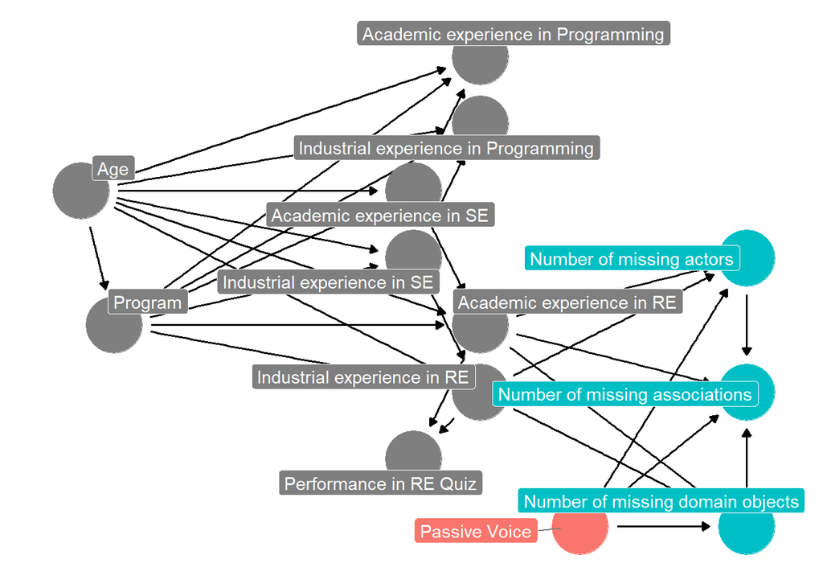

```r
dag <- dagify(
  Program ~ Age,
  ExpSEAca ~ Program + Age,
  ExpSEInd ~ Program + Age,
  ExpProgAca ~ Program + Age + ExpSEAca,
  ExpProgInd ~ Program + Age + ExpSEInd,
  ExpREAca ~ Program + Age + ExpSEAca,
  ExpREInd ~ Program + Age + ExpSEInd,
  REQuizPerformance ~ ExpREAca + ExpREInd,
  actors.missing ~ ExpREAca + ExpREInd + passive,
  entities.missing ~ ExpREAca + ExpREInd + passive,
  associations.missing ~ ExpREAca + ExpREInd + passive + actors.missing + entities.missing,
  exposure = "passive", outcome = c("actors.missing", "entities.missing", "associations.missing"),
  labels = c(Age = "Age", Program = "Program", ExpSEAca = "Academic experience in SE", ExpSEInd = "Industrial experience in SE", ExpProgAca = "Academic experience in Programming", ExpProgInd = "Industrial experience in Programming", ExpREAca = "Academic experience in RE", ExpREInd = "Industrial experience in RE", REQuizPerformance = "Performance in RE Quiz", passive = "Passive Voice", actors.missing = "Number of missing actors", entities.missing = "Number of missing domain objects", associations.missing = "Number of missing associations"),

  coords = list(
    x=c(Age=0, Program=0.2, ExpProgAca=2.4, ExpProgInd=2.4, ExpSEAca=2, ExpSEInd=2, ExpREAca=2.4, ExpREInd=2.4, REQuizPerformance=2, passive=3, actors.missing=4, associations.missing=4,entities.missing=4),
    y=c(Age=-1, Program=-2, ExpProgAca=0, ExpProgInd=-0.5, ExpSEAca=-1, ExpSEInd=-1.5, ExpREAca=-2, ExpREInd=-2.5, REQuizPerformance=-3, passive=-3.5, actors.missing=-1.5, associations.missing=-2.5,entities.missing=-3.5)
  )
)

dag.plot.full <- ggdag_status(dag, use_labels="label", text=FALSE) +
  guides(fill = "none", color="none") +
  theme_dag()
dag.plot.full
```

## Identification

During the identification step, we determine the variables relevant to be included in our regression model depending on the hypotheses we want to answer

### Adjustment sets

```r
adjustmentSets(dag, exposure="passive", outcome="actors.missing", effect="direct")
```

```
##  {}
```

```r
adjustmentSets(dag, exposure="passive", outcome="entities.missing", effect="direct")
```

```
##  {}
```

```r
adjustmentSets(dag, exposure="passive", outcome="associations.missing", effect="direct")
```

```
## { ExpREAca, ExpREInd, actors.missing, entities.missing }
```

### Reduced DAG

Based on these adjustment sets, we consider the following subset of the original DAG as complete for our causal inference:

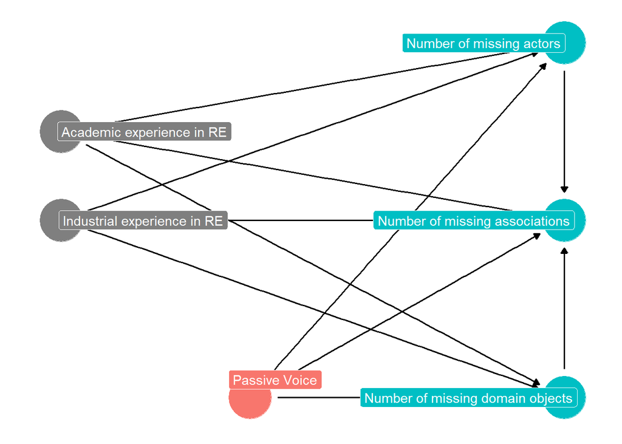

```r
dag <- dagify(
  actors.missing ~ ExpREAca + ExpREInd + passive,
  entities.missing ~ ExpREAca + ExpREInd + passive,
  associations.missing ~ ExpREAca + ExpREInd + passive + actors.missing + entities.missing,
  exposure = "passive", outcome = c("actors.missing", "entities.missing", "associations.missing"),
  labels = c(Age = "Age", Program = "Program", ExpSEAca = "Academic experience in SE", ExpSEInd = "Industrial experience in SE", ExpProgAca = "Academic experience in Programming", ExpProgInd = "Industrial experience in Programming", ExpREAca = "Academic experience in RE", ExpREInd = "Industrial experience in RE", REQuizPerformance = "Performance in RE Quiz", passive = "Passive Voice", actors.missing = "Number of missing actors", entities.missing = "Number of missing domain objects", associations.missing = "Number of missing associations"),

  coords = list(
    x=c(ExpREAca=2.4, ExpREInd=2.4, passive=3, actors.missing=4, associations.missing=4,entities.missing=4),
    y=c(ExpREAca=-2, ExpREInd=-2.5, passive=-3.5, actors.missing=-1.5, associations.missing=-2.5,entities.missing=-3.5)
  )
)

dag.plot.reduced <- ggdag_status(dag, use_labels="label", text=FALSE) +
  guides(fill = "none", color="none") +
  theme_dag()

dag.plot.reduced
```

This will be the DAG we use for the final step, the estimation.

[^1]: Siebert, J. (2023). Applications of statistical causal inference in software engineering. Information and Software Technology, 107198.
[^2]: Femmer, H., Kučera, J., & Vetrò, A. (2014, September). On the impact of passive voice requirements on domain modelling. In Proceedings of the 8th ACM/IEEE International Symposium on Empirical Software Engineering and Measurement (pp. 1-4).